# Experimental design for sequencing-based spatial transcriptomics with spaDesign

Juan Xie

2026-05-18

## Overview

`spaDesign` is a simulation-based framework for experimental design in sequencing-based spatial transcriptomics studies. The package is designed to help answer a practical question before committing to a full experiment:

> How much sequencing depth is enough to recover the spatial domains of interest?

Starting from a pilot spatial transcriptomics dataset, `spaDesign` learns domain-specific expression and spatial patterns, simulates new datasets under candidate sequencing depths and signal strengths, evaluates domain recovery, and detects the sequencing depth at which additional reads provide diminishing returns.

The typical workflow is:

1. Create a `spaDesign` object from a count matrix and spatial metadata.
2. Select domain-informative genes.
3. Estimate the spatial distribution and spatial expression models.
4. Simulate data across sequencing depth and perturbation settings.
5. Evaluate domain recovery with normalized mutual information (NMI).
6. Detect and visualize the saturation sequencing depth.

## Installation and setup

Install the development version from GitHub:

```r
if (!requireNamespace("devtools", quietly = TRUE)) {
  install.packages("devtools")
}

devtools::install_github("JuanXie19/spaDesign")
```

Load the package:

```r
suppressWarnings(suppressPackageStartupMessages(library(spaDesign)))
```

## Input data

The core input is a gene-by-spot count matrix and a spot-level metadata table. The metadata must contain at least three columns:

- `x`: spatial x coordinate
- `y`: spatial y coordinate
- `domain`: known or estimated spatial domain label

The column names of the count matrix must match the row names of the metadata.

```r
dim(count_matrix)
head(loc)

all(colnames(count_matrix) == rownames(loc))
```

`spaDesign` also ships example/reference data under `inst/extdata`. A small example object can be loaded as follows:

```r
example_path <- system.file("extdata", "exampleData.rds", package = "spaDesign")
example_data <- readRDS(example_path)

count_matrix <- example_data$count
loc <- example_data$loc

dim(count_matrix)
```

```
#> [1]   73 3611
```

```r
head(loc)
```

```
#>                       x    y domain
#> AAACAAGTATCTCCCA-1 8468 9791 Layer3
#> AAACAATCTACTAGCA-1 2807 5769 Layer1
#> AAACACCAATAACTGC-1 9505 4068     WM
#> AAACAGAGCGACTCCT-1 4151 9271 Layer3
#> AAACAGCTTTCAGAAG-1 7583 3393 Layer5
#> AAACAGGGTCTATATT-1 8064 3665 Layer6
```

## Create a spaDesign object

Use `createDesignObject()` to initialize the S4 object used throughout the analysis.

```r
DATA <- createDesignObject(
  count_matrix = count_matrix,
  loc = loc
)

DATA
```

```
#> class: spaDesign
#> Reference dim: 73 3611
#> Reference rownames (first 5): CAMK2N1, STMN1, RPS8, ATP1B1, VSNL1 , ...
#> Reference colnames (first 5): AAACAAGTATCTCCCA-1, AAACAATCTACTAGCA-1, AAACACCAATAACTGC-1, AAACAGAGCGACTCCT-1, AAACAGCTTTCAGAAG-1 , ...
#> refcolData names: x, y, domain
#> Simulated Count dim: 0 0
#> Simulated Count rownames (first 5): NULL
#> Simulated Count colnames (first 5): NULL
#> simcolData names:
```

The object stores the reference count matrix, spot metadata, simulated data, model parameters, selected genes, and downstream evaluation metrics. We can access them via the *@* operator

```r
dim(DATA@refCounts)
```

```
#> [1]   73 3611
```

```r
head(DATA@refcolData)
```

```
#>                       x    y domain
#> AAACAAGTATCTCCCA-1 8468 9791 Layer3
#> AAACAATCTACTAGCA-1 2807 5769 Layer1
#> AAACACCAATAACTGC-1 9505 4068     WM
#> AAACAGAGCGACTCCT-1 4151 9271 Layer3
#> AAACAGCTTTCAGAAG-1 7583 3393 Layer5
#> AAACAGGGTCTATATT-1 8064 3665 Layer6
```

## Select domain-informative genes

`featureSelection()` identifies genes informative for each spatial domain. These genes are used to estimate and simulate domain-specific expression patterns.

```r
DATA <- featureSelection(
  spaDesign = DATA,
  logfc_cutoff = 0.7,
  mean_in_cutoff = 1.8,
  max_num_gene = 10,
  n_cores = 4
)
```

```
#> Completed fold change calculations for all domains
#> Completed gene selection for all domains.
```

```r
lapply(topGenes(DATA), head)
```

```
#> $Layer1
#>           logFC   logFC_low  mean_in mean_out mean_out_low
#> FTH1 -0.9829698 -0.59803704 1.949164 2.932134     2.547201
#> MT3  -0.6526200 -0.23204143 2.025134 2.677754     2.257176
#> CST3 -0.4823408 -0.07583047 1.970889 2.453230     2.046719
#> CLU  -0.5021162 -0.04516430 1.887078 2.389194     1.932242
#>
#> $Layer2
#>             logFC logFC_low  mean_in mean_out mean_out_low
#> ENC1    0.7389764  1.416254 2.308974 1.569998    0.8927208
#> CAMK2N1 0.7561904  1.255235 2.360751 1.604560    1.1055160
#> MALAT1  0.5954564  1.109941 2.034359 1.438902    0.9244180
#> CCK     0.4457882  1.073499 2.192328 1.746540    1.1188290
#> NRGN    0.4316967  1.006134 2.758569 2.326872    1.7524350
#> VSNL1   0.3661212  1.004916 2.223147 1.857026    1.2182311
#>
#> $Layer3
#>           logFC logFC_low  mean_in mean_out mean_out_low
#> ENC1  0.8987795  1.537496 2.274390 1.375611    0.7368948
#> CCK   0.7549431  1.365506 2.325948 1.571005    0.9604420
#> YWHAH 0.7283554  1.346714 2.344730 1.616374    0.9980157
#> OLFM1 0.6622579  1.317705 2.290049 1.627791    0.9723440
#> NRGN  0.7117987  1.293658 2.873966 2.162167    1.5803081
#> RTN1  0.5623460  1.232325 2.189878 1.627532    0.9575537
#>
#> $Layer4
#>            logFC logFC_low  mean_in mean_out mean_out_low
#> NEFL   0.6068082  1.165635 1.894854 1.288046    0.7292193
#> SNAP25 0.4337693  1.111824 2.720310 2.286541    1.6084860
#> UCHL1  0.4151512  1.039020 2.184492 1.769340    1.1454719
#> ATP1B1 0.4304797  1.030161 2.201401 1.770921    1.1712399
#> RTN1   0.3550022  1.014821 2.115121 1.760119    1.1002999
#> TUBA1B 0.4279989  1.010564 2.594543 2.166544    1.5839789
#>
#> $Layer5
#>            logFC logFC_low  mean_in mean_out mean_out_low
#> SNAP25 0.6334700  1.301212 2.828135 2.194665    1.5269227
#> TMSB10 0.6879465  1.228160 2.853959 2.166013    1.6257990
#> SYT1   0.6115424  1.177087 2.106545 1.495003    0.9294578
#> TUBB2A 0.5754830  1.142939 2.100406 1.524923    0.9574672
#> VSNL1  0.4261278  1.125050 2.229386 1.803258    1.1043356
#> RTN1   0.4739182  1.100971 2.167142 1.693224    1.0661709
#>
#> $Layer6
#>          logFC logFC_low  mean_in mean_out mean_out_low
#> MBP  0.3941332  1.174203 2.656200 2.262067    1.4819975
#> PLP1 0.3343549  1.161692 1.975242 1.640887    0.8135499
#>
#> $WM
#>          logFC logFC_low  mean_in  mean_out mean_out_low
#> PLP1  2.176285  2.734985 3.572071 1.3957861    0.8370865
#> MBP   2.079010  2.617279 4.121251 2.0422408    1.5039723
#> CRYAB 1.643144  2.136243 2.499826 0.8566822    0.3635833
#> CNP   1.639491  2.090467 2.433547 0.7940568    0.3430807
#> GFAP  1.677262  2.013622 2.622706 0.9454439    0.6090845
#> TF    1.456752  1.914401 1.914401 0.4576482    0.0000000
```

The thresholds could be tuned. A stricter `logfc_cutoff` selects genes with stronger domain contrast, while a higher `mean_in_cutoff` filters genes that are weakly expressed inside the domain.

## Estimate model parameters

`spaDesign` estimates two complementary parts of the spatial transcriptomics signal:

- `estimation_FGEM()` learns domain location spatial distribution patterns.
- `estimation_NNGP()` learns spatial expression patterns for selected genes.

```r
DATA <- estimation_FGEM(
  spaDesign = DATA,
  iter_max = 1000,
  M_candidates = 2:6,
  tol = 0.1,
  n_cores = 4,
  verbose = FALSE
)

DATA <- estimation_NNGP(
  spaDesign = DATA,
  n_neighbors = 10,
  order = "AMMD",
  X = NULL,
  verbose = FALSE
)
```

After this step, the object contains the fitted parameters needed for simulation.

The fitted object contains selected genes and model parameters.

Specifically, the estimated NNGP parameters are stored by domain and gene. For example, `Layer1` and gene `FTH1` contain an estimated regression coefficient:

```
#>   beta_1
#> 2.040759
```

The estimated FGEM parameters are stored by domain. For example, the mixing proportions from the AIC-selected model for `Layer1` are:

```
#> [1] 0.2381040 0.2656806 0.1318387 0.1501832 0.2141935
```

## Power analysis over sequencing depth and effect size

`powerAnalysisEffectSize()` simulates datasets over a grid of sequencing depth scaling factors and effect size scaling factors. Domain recovery is evaluated by NMI after clustering the simulated data.

```r
effect_results <- powerAnalysisEffectSize(
  spaDesign = DATA,
  es_range = c(0.5, 1, 2),
  seq_depth_range = c(0.5, 1, 2, 3, 5, 7, 10),
  n_rep = 3,
  n_cores = 4
)

head(effect_results)
```

```
#>   seq_depth effect_size total_counts       NMI
#> 1       0.5         0.5       472626 0.1031901
#> 2       1.0         0.5       945303 0.2615199
#> 3       2.0         0.5      1895226 0.6182607
#> 4       3.0         0.5      2843979 0.6874330
#> 5       5.0         0.5      4750715 0.6736365
#> 6       7.0         0.5      6652783 0.7966580
```

The output contains one row per simulation replicate and scenario:

- `seq_depth`: relative sequencing depth compared with the pilot dataset
- `effect_size`: signal scaling factor
- `total_counts`: total counts in the simulated dataset
- `NMI`: agreement between inferred and true domain labels

If the pilot experiment has an observed depth in millions of reads or UMIs, the relative scale can be converted to an absolute scale:

```r
pilot_depth <- sum(refCounts(DATA)) / 1e6
effect_results$absolute_depth <- effect_results$seq_depth * pilot_depth
```

## Power analysis under spatial perturbation

Spatial perturbation analysis evaluates robustness when a fraction of genes deviate from the undisturbed spatial pattern.

```r
spatial_results <- powerAnalysisSpatial(
  spaDesign = DATA,
  SIGMA = 1,
  prop_range = c(0.6, 0.8, 1.0),
  seq_depth_range = c(0.5, 1, 2, 3, 5, 7, 10),
  n_rep = 5,
  n_cores = 4
)

head(spatial_results)
```

[output not shown]

Here, `prop_range` controls the proportion of genes that retain the original spatial pattern, and `SIGMA` controls the spatial noise level.

## Detect sequencing depth saturation

The saturation point is estimated by fitting a monotone smooth curve between sequencing depth and NMI. The detected saturation depth is the first point where the fitted curve has sufficiently small marginal improvement after reaching a specified fraction of its maximum performance.

```r
sat_effect <- saturationDetection(
  data = effect_results,
  metric_col = "NMI",
  depth_col = "seq_depth",
  group_cols = "effect_size",
  pilot_depth = NULL,
  slope_threshold = 0.05,
  required_metric_percentage = 0.8,
  aggregate_reps = TRUE
)

sat_effect$summary
```

```
#>     group saturation_depth saturation_metric warning
#> 0.5   0.5        3.0301508         0.6926797
#> 1       1        2.6005025         0.7847970
#> 2       2        0.5477387         0.7586650
```

Important tuning parameters:

- `slope_threshold`: lower values require a flatter curve before declaring saturation.
- `required_metric_percentage`: higher values require the curve to get closer to its maximum before saturation is considered.
- `aggregate_reps`: when `TRUE`, replicate results at the same sequencing depth are averaged before curve fitting.

Visualize the fitted curves and detected saturation depths:

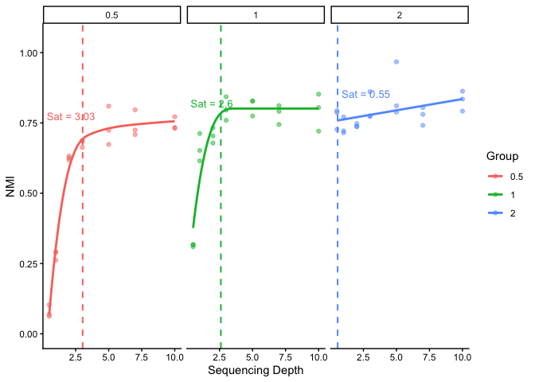

```r
plotSaturation(
  sat_effect,
  metric_col = "NMI",
  use_absolute = TRUE,
  facet = TRUE,
  label_saturation = TRUE
)
```

## Interactive Shiny workflow

The package includes a Shiny application with two main steps:

1. Data preparation: choose a built-in reference dataset or upload SpaceRanger output files.
2. Sequencing depth estimation: run baseline, effect-size, or spatial perturbation simulations and visualize the saturation curve.

Launch the app from an installed package:

```r
library(spaDesign)

runSpaDesignApp()
```

For uploaded data, the app expects:

- `filtered_feature_bc_matrix.h5`
- `tissue_positions_list.csv`
- optional annotation CSV with `barcode` and `domain` columns

If no annotation file is provided, the app estimates spatial domains from the uploaded count matrix.

## A minimal end-to-end template

The following template summarizes the full analysis:

```r
library(spaDesign)

example_data <- readRDS(system.file("extdata", "exampleData.rds", package = "spaDesign"))

DATA <- createDesignObject(
  count_matrix = example_data$count,
  loc = example_data$loc
)

DATA <- featureSelection(
  DATA,
  logfc_cutoff = 0.7,
  mean_in_cutoff = 1.8,
  max_num_gene = 10,
  n_cores = 4
)

DATA <- estimation_FGEM(
  DATA,
  iter_max = 1000,
  M_candidates = 2:6,
  tol = 0.1,
  n_cores = 4,
  verbose = FALSE
)

DATA <- estimation_NNGP(
  DATA,
  n_neighbors = 10,
  order = "AMMD",
  X = NULL,
  verbose = FALSE
)

rst <- powerAnalysisEffectSize(
  DATA,
  es_range = c(1, 2),
  seq_depth_range = c(0.5, 1, 2, 3, 5, 7, 10),
  n_rep = 5,
  n_cores = 4
)

pilot_depth <- sum(refCounts(DATA)) / 1e6

sat <- saturationDetection(
  rst,
  group_cols = "effect_size",
  pilot_depth = pilot_depth,
  aggregate_reps = TRUE
)

sat$summary
plotSaturation(sat)
```

## Practical recommendations

Use a pilot dataset that is representative of the tissue, chemistry, and expected domain structure of the planned study. The saturation depth estimated by `spaDesign` is conditional on this pilot signal.

Start with a modest grid such as `seq_depth_range = c(0.5, 1, 2, 3, 5, 7, 10)` and increase `n_rep` after confirming that the pipeline runs successfully.

When comparing multiple experimental conditions, interpret the recommended depth alongside the achieved NMI. A low saturation depth with a low maximum NMI may indicate that sequencing depth is not the main limiting factor.